# 市场观察

## D、择时

### (d1)等权指数

从历史来看，A股市场存在小盘股效应，市值小的股票长期整体跑赢大市值的股票，美股市场同样存在类似的现象。而目前大部分指数的编制方案都是类似市值加权，为了抛去市值的影响，下面展示几个等权指数，其中中证500等权和沪深300等权是现有的指数，中证全指等权是自己编制的指数。等权指数可以视为一个更好地业绩比较基准。等权指数走势如下图：

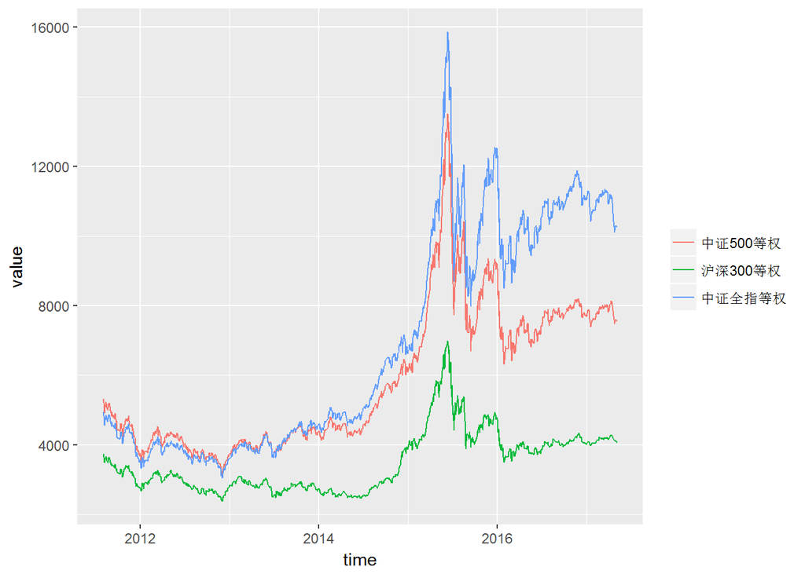

等权指数收益率统计见下表：

|  | 中证500等权 | 沪深300等权 | 中证全指等权 |
| --- | --- | --- | --- |
| 2011-08-02 ~ 2011-12-30 | -29.2% | -25.5% | -27.8% |
| 2012-01-04 ~ 2012-12-31 | -0.0% | 1.5% | 2.2% |
| 2013-01-04 ~ 2013-12-31 | 16.7% | -3.2% | 25.8% |
| 2014-01-02 ~ 2014-12-31 | 40.2% | 43.7% | 46.0% |
| 2015-01-05 ~ 2015-12-31 | 47.6% | 20.1% | 84.4% |
| 2016-01-04 ~ 2016-12-30 | -15.1% | -15.1% | -10.3% |
| 2017-01-03 ~ 2017-05-04 | -2.0% | 1.1% | -7.2% |
| 累计收益率 | 42.3% | 8.6% | 108.0% |
| 年化收益率 | 6.3% | 1.4% | 13.6% |
| 年化波动率 | 28.6% | 25.9% | 28.9% |
| 年化Sharpe值 | 22.1% | 5.6% | 46.8% |
| 最大回撤 | 53.3% | 50.0% | 49.7% |

### (d2)大盘均线强弱指数

大盘均线强弱指数在一定程度上可以视为一个反转指标，当大盘均线得分接近8分时，预示市场接近顶部，当大盘均线得分接近0分时，预示市场接近底部。  
大盘均线强弱指数近一年来走势如下图：

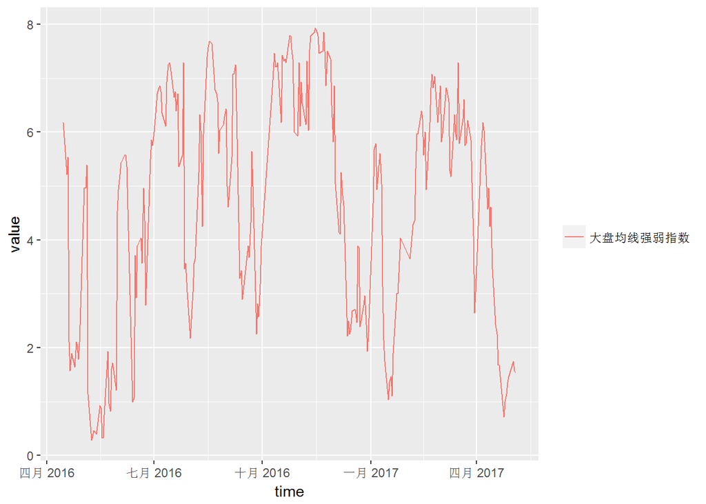

申万一级行业的最新得分见下表：

| 日期 | 指数代码 | 行业 | 最新得分 | 上周得分 |
| --- | --- | --- | --- | --- |
| 2017-05-04 | EI801110 | 家用电器 | 8 | 8 |
| 2017-05-04 | EI801710 | 建筑材料 | 6 | 3 |
| 2017-05-04 | EI801160 | 公用事业 | 5 | 4 |
| 2017-05-04 | EI801170 | 交通运输 | 4 | 3 |
| 2017-05-04 | EI801720 | 建筑装饰 | 4 | 3 |
| 2017-05-04 | EI801040 | 钢铁 | 3 | 1 |
| 2017-05-04 | EI801080 | 电子 | 3 | 2 |
| 2017-05-04 | EI801120 | 食品饮料 | 3 | 8 |
| 2017-05-04 | EI801030 | 化工 | 1 | 0 |
| 2017-05-04 | EI801130 | 纺织服装 | 1 | 0 |
| 2017-05-04 | EI801140 | 轻工制造 | 1 | 0 |
| 2017-05-04 | EI801200 | 商业贸易 | 1 | 0 |
| 2017-05-04 | EI801730 | 电气设备 | 1 | 0 |
| 2017-05-04 | EI801750 | 计算机 | 1 | 0 |
| 2017-05-04 | EI801890 | 机械设备 | 1 | 0 |
| 2017-05-04 | EI801010 | 农林牧渔 | 0 | 0 |
| 2017-05-04 | EI801020 | 采掘 | 0 | 0 |
| 2017-05-04 | EI801050 | 有色金属 | 0 | 0 |
| 2017-05-04 | EI801150 | 医药生物 | 0 | 0 |
| 2017-05-04 | EI801180 | 房地产 | 0 | 0 |
| 2017-05-04 | EI801210 | 休闲服务 | 0 | 0 |
| 2017-05-04 | EI801230 | 综合 | 0 | 0 |
| 2017-05-04 | EI801740 | 国防军工 | 0 | 0 |
| 2017-05-04 | EI801760 | 传媒 | 0 | 1 |
| 2017-05-04 | EI801770 | 通信 | 0 | 0 |
| 2017-05-04 | EI801780 | 银行 | 0 | 1 |
| 2017-05-04 | EI801790 | 非银金融 | 0 | 3 |
| 2017-05-04 | EI801880 | 汽车 | 0 | 1 |

### (d3)LLT及均线择时

LLT本质上是一个改进的单均线择时指标，较原始的均线择时延迟更低。  
择时模型和指数本身的净值走势如下图：

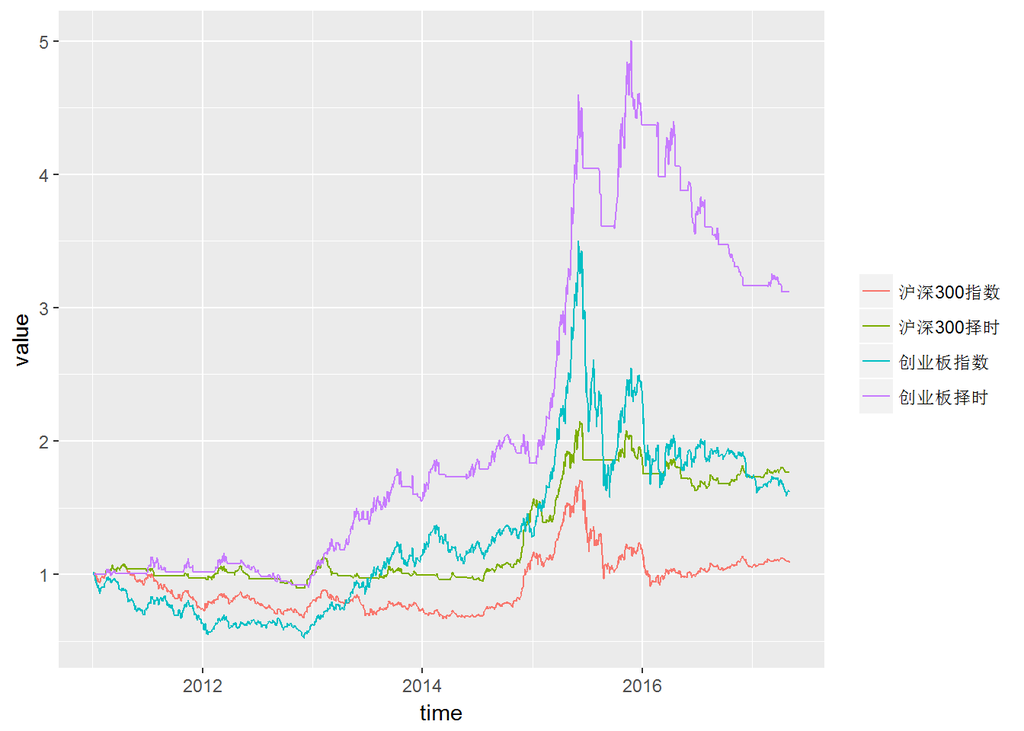

择时模型和指数的收益率统计如下表：

|  | 沪深300指 | 沪深300LLT | 创业板指 | 创业板MA |
| --- | --- | --- | --- | --- |
| 2011-01-04 ~ 2011-12-30 | -25.0% | -2.5% | -35.9% | 1.9% |
| 2012-01-04 ~ 2012-12-31 | 7.6% | 5.4% | -2.1% | -1.7% |
| 2013-01-04 ~ 2013-12-31 | -7.6% | -3.2% | 82.7% | 55.7% |
| 2014-01-02 ~ 2014-12-31 | 51.7% | 52.4% | 12.8% | 17.7% |
| 2015-01-05 ~ 2015-12-31 | 5.6% | 24.3% | 84.4% | 138.1% |
| 2016-01-04 ~ 2016-12-30 | -11.3% | -8.1% | -27.7% | -27.5% |
| 2017-01-03 ~ 2017-05-04 | 2.8% | 1.9% | -6.3% | -1.6% |
| 累计收益率 | 8.8% | 76.7% | 61.6% | 211.7% |
| 年化收益率 | 1.3% | 9.4% | 7.9% | 19.6% |
| 年化波动率 | 24.0% | 15.4% | 32.6% | 21.9% |
| 年化Sharpe值 | 5.6% | 61.1% | 24.1% | 89.5% |
| 最大回撤 | 46.7% | 24.0% | 54.9% | 37.7% |

择时模型最近10个交易日的信号如下表：

| 日期 | 沪深300收盘价 | 沪深300LLT | 沪深300择时信号 | 创业板收盘价 | 创业板MA30 | 创业板择时信号 |
| --- | --- | --- | --- | --- | --- | --- |
| 2017-04-20 | 3461.548 | 3490.553 |  | 1850.390 | 1928.067 |  |
| 2017-04-21 | 3466.787 | 3490.200 |  | 1839.006 | 1923.880 |  |
| 2017-04-24 | 3431.259 | 3488.856 |  | 1809.911 | 1919.078 |  |
| 2017-04-25 | 3440.974 | 3486.717 |  | 1818.870 | 1914.707 |  |
| 2017-04-26 | 3445.183 | 3485.115 |  | 1820.481 | 1909.694 |  |
| 2017-04-27 | 3446.720 | 3483.757 |  | 1842.922 | 1905.857 |  |
| 2017-04-28 | 3439.753 | 3482.270 |  | 1850.734 | 1902.288 |  |
| 2017-05-02 | 3426.577 | 3480.182 |  | 1850.849 | 1898.425 |  |
| 2017-05-03 | 3413.128 | 3477.312 |  | 1840.453 | 1894.785 |  |
| 2017-05-04 | 3404.386 | 3473.844 |  | 1838.104 | 1890.928 |  |

### (d4)网格交易

在经历了三轮股灾，A股逐步回归正常，在过去的一段时间呈现一个震荡的格局，如果未来没有增量信息，很可能维持震荡。结合股指期货的贴水，前期研究了一下网格交易。网格交易的结果如下图：

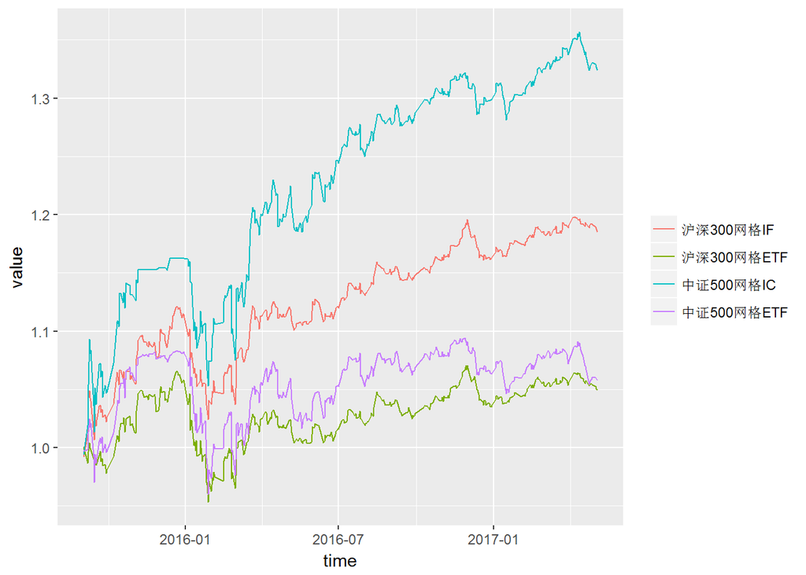

网格交易的收益统计如下表：

|  | 沪深300指数 | 沪深300网格IF | 沪深300网格ETF | 中证500指数 | 中证500网格IC | 中证500网格ETF |
| --- | --- | --- | --- | --- | --- | --- |
| 2015-09-02 ~ 2015-12-31 | 11.0% | 11.1% | 5.6% | 23.5% | 16.2% | 8.1% |
| 2016-01-04 ~ 2016-12-30 | -11.3% | 4.7% | -1.8% | -17.8% | 11.8% | -1.6% |
| 2017-01-03 ~ 2017-05-04 | 2.8% | 1.9% | 1.2% | -1.4% | 1.9% | -0.6% |
| 累计收益率 | 1.3% | 18.5% | 4.9% | 0.1% | 32.4% | 5.7% |
| 年化收益率 | 0.7% | 10.7% | 2.9% | 0.1% | 18.2% | 3.4% |
| 年化波动率 | 21.3% | 8.9% | 8.7% | 28.8% | 13.2% | 11.2% |
| 年化Sharpe值 | 3.5% | 119.5% | 33.5% | 0.2% | 138.7% | 30.1% |
| 最大回撤 | 26.4% | 8.6% | 10.5% | 33.5% | 9.4% | 11.4% |

## E、选股

### (e1)超级小盘股

作为多因子选股的第一部分，有必要从市值因子说起。 下面利用总市值因子，在中证全指的成分股内，选出市值最小的100只股票，这里剔除了ST、新上市、停牌和涨停的股票，100只股票等权配置，每月换仓一次，交易成本千分之三。超级小盘股策略的净值表现如下图。

[output not shown]

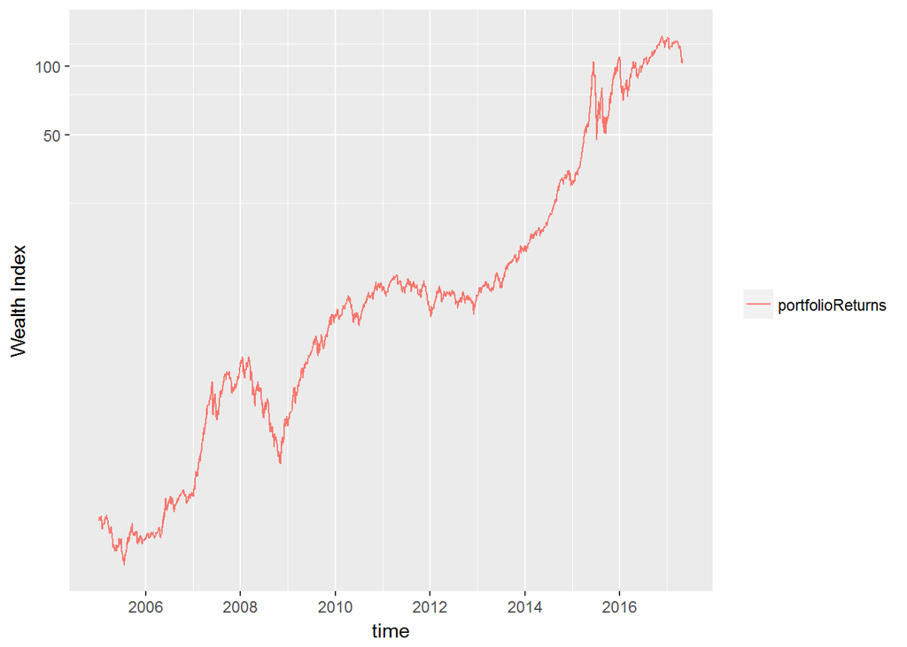

超级小盘股的收益统计如下表：

|  | 超级小盘股 | 沪深300 | 中证500 |
| --- | --- | --- | --- |
| 2005-01-05 ~ 2005-12-30 | -16.7% | -6.0% | -12.8% |
| 2006-01-04 ~ 2006-12-29 | 55.8% | 121.0% | 100.7% |
| 2007-01-04 ~ 2007-12-28 | 265.1% | 161.5% | 186.6% |
| 2008-01-02 ~ 2008-12-31 | -44.5% | -65.9% | -60.8% |
| 2009-01-05 ~ 2009-12-31 | 205.8% | 96.7% | 131.3% |
| 2010-01-04 ~ 2010-12-31 | 32.2% | -12.5% | 10.5% |
| 2011-01-04 ~ 2011-12-30 | -19.4% | -25.0% | -33.8% |
| 2012-01-04 ~ 2012-12-31 | 15.3% | 7.6% | 0.3% |
| 2013-01-04 ~ 2013-12-31 | 63.3% | -7.6% | 16.9% |
| 2014-01-02 ~ 2014-12-31 | 88.8% | 51.7% | 39.0% |
| 2015-01-05 ~ 2015-12-31 | 254.4% | 5.6% | 43.1% |
| 2016-01-04 ~ 2016-12-30 | 21.2% | -11.3% | -17.8% |
| 2017-01-03 ~ 2017-05-04 | -17.8% | 2.8% | -1.4% |
| 累计收益率 | 10644.5% | 246.4% | 528.0% |
| 年化收益率 | 46.2% | 10.6% | 16.1% |
| 年化波动率 | 35.7% | 28.3% | 32.3% |
| 年化Sharpe值 | 129.3% | 37.4% | 49.7% |
| 最大回撤 | 66.3% | 72.3% | 72.4% |

### (e2)银行股轮动

银行股轮动是参考集思录的热门贴银行股评级而来的，数据的提取和参数的设置和原贴有一定的差别，所以轮动的效果也会不太一样，不过回测的效果还不错，从现在开始跟踪。2013年以来银行股轮动的结果如下图：

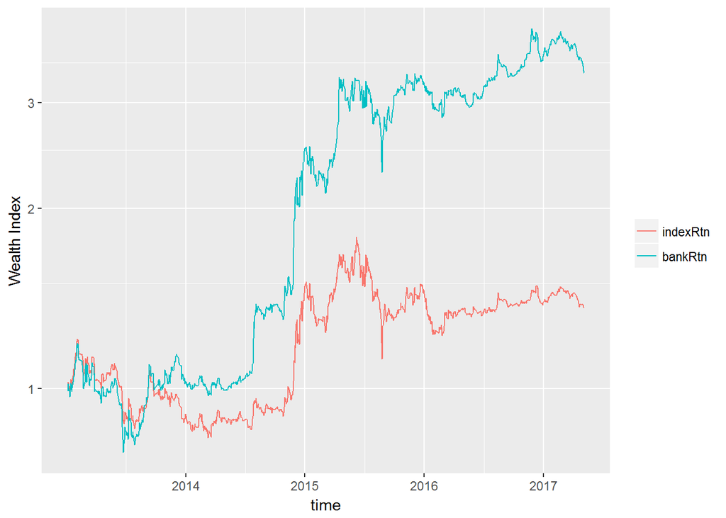

银行股轮动的收益统计如下表：

|  | 申万银行 | 银行股轮动 |
| --- | --- | --- |
| 2013-01-04 ~ 2013-12-31 | -9.2% | 3.0% |
| 2014-01-02 ~ 2014-12-31 | 63.2% | 144.5% |
| 2015-01-05 ~ 2015-12-31 | -1.4% | 29.0% |
| 2016-01-04 ~ 2016-12-30 | -4.9% | 10.5% |
| 2017-01-03 ~ 2017-05-04 | -2.0% | -6.3% |
| 累计收益率 | 36.1% | 236.5% |
| 年化收益率 | 7.4% | 32.3% |
| 年化波动率 | 28.0% | 31.9% |
| 年化Sharpe值 | 26.4% | 101.3% |
| 最大回撤 | 37.4% | 34.2% |

银行股轮动的最新得分如下表：

| 日期 | 代码 | 简称 | PB | 预期ROE | 翻倍期 | 持仓 |
| --- | --- | --- | --- | --- | --- | --- |
| 2017-05-04 | EQ600015 | 华夏银行 | 0.70 | 0.15 | 2.5 | hold |
| 2017-05-04 | EQ601818 | 光大银行 | 0.68 | 0.11 | 3.1 |  |
| 2017-05-04 | EQ601328 | 交通银行 | 0.68 | 0.10 | 3.2 |  |
| 2017-05-04 | EQ601988 | 中国银行 | 0.72 | 0.11 | 3.4 |  |
| 2017-05-04 | EQ000001 | 平安银行 | 0.72 | 0.11 | 3.7 |  |
| 2017-05-04 | EQ600016 | 民生银行 | 0.79 | 0.13 | 3.8 |  |
| 2017-05-04 | EQ601288 | 农业银行 | 0.79 | 0.13 | 3.8 |  |
| 2017-05-04 | EQ601998 | 中信银行 | 0.74 | 0.10 | 4.0 |  |
| 2017-05-04 | EQ601166 | 兴业银行 | 0.81 | 0.13 | 4.1 |  |
| 2017-05-04 | EQ600000 | 浦发银行 | 0.85 | 0.13 | 4.2 |  |
| 2017-05-04 | EQ601398 | 工商银行 | 0.84 | 0.13 | 4.3 |  |
| 2017-05-04 | EQ601939 | 建设银行 | 0.90 | 0.13 | 4.7 |  |
| 2017-05-04 | EQ601169 | 北京银行 | 0.90 | 0.12 | 5.2 |  |
| 2017-05-04 | EQ601009 | 南京银行 | 0.97 | 0.14 | 5.2 |  |
| 2017-05-04 | EQ600036 | 招商银行 | 1.12 | 0.14 | 6.0 |  |
| 2017-05-04 | EQ002142 | 宁波银行 | 1.28 | 0.16 | 6.4 |  |
| 2017-05-04 | EQ601229 | 上海银行 | 1.13 | 0.12 | 7.0 |  |
| 2017-05-04 | EQ601997 | 贵阳银行 | 1.63 | 0.17 | 7.5 |  |
| 2017-05-04 | EQ600919 | 江苏银行 | 1.25 | 0.13 | 7.6 |  |
| 2017-05-04 | EQ600926 | 杭州银行 | 1.43 | 0.11 | 10.4 |  |
| 2017-05-04 | EQ601128 | 常熟银行 | 2.98 | 0.10 | 18.0 |  |
| 2017-05-04 | EQ600908 | 无锡银行 | 4.08 | 0.10 | 21.9 |  |
| 2017-05-04 | EQ603323 | 吴江银行 | 2.77 | 0.08 | 22.1 |  |
| 2017-05-04 | EQ002807 | 江阴银行 | 3.98 | 0.09 | 25.4 |  |